# Process LTER Unispec Data

Ruby An

December 17, 2018

# 1 How to use this R Markdown Notebook:

This R Markdown document walks through processing historic (already collected) unispec data from 2010-2018.

# 2 Choose Directory

Select the folder containing the unispec files you want to process. Run the following code chunk interactively in RStudio to set folder via pop-up window.

```r
if (interactive()) {
  ## INTERACTIVE CODE (use when in RStudio)
  library("rChoiceDialogs") # for interactively selecting file directories
data_path <- rchoose.dir(caption = "Select Unispec files directory")
} else {
  ## STATIC CODE (use when Knitting)
  data_path  <- "UnispecData/Unispec6/"
}
```

**Chosen Directory**: /home/ruby/UnispecR/UnispecData/2017/spu

This directory should contain both the `.spu` files you wish to process and a corresponding `*_unispec_key.csv` file. The key file matches the .spu files to the date, site, block, treatment, plot, & measurement and specifies which white references to use to correct for instrument error.

# 3 Load Unispec Data

Run the following code chunks to load & join keys to data from your chosen directory.

## 3.1 Load Keys

Select unispec key files interactively or search within: /home/ruby/UnispecR/UnispecData/2017/spu.

```r
if (interactive()) {
  key_files <- rchoose.files() # choose via window
} else {
  ## Find all file keys matching search pattern
  key_files <- list.files(path = data_path, pattern = "*_key.csv", full.names = T, recursive = T)
}
## Read in data from filekeys
key_list <- data_frame(keyname = key_files) %>% # create dataframe
  mutate(key_contents = map(keyname, function(x) read_key_file(x)))
# read_key_file() is a function I wrote located in the file "unispec_functions.R"
# map function: super useful to apply function to objects without slow "for" loops
## Unpack into usable dataframe
keys <- unnest(key_list)
```

**Chosen Keys**: /home/ruby/UnispecR/UnispecData/2017/2017_unispec_key.csv

## 3.2 Load Data

You can choose to select unispec data files interactively; however, it is usally more convenient to let R search: /home/ruby/UnispecR/UnispecData/2017/spu – for all `.spu` files. This step may take several minutes, if you chose a folder containing many files.

```r
#interact <- interactive() # T or F value
interact <- F # set to F to search for a file name pattern instead of select via window
if (interact) {
  files <- rchoose.files(filter=c("*.spu")) # choose via window
} else {
  ## Find .spu files via search pattern: specify Date(s) or Site(s) to read files
  files <- list.files(path = data_path, pattern = ".spu$", full.names = T, recursive=T)
}
## Read data from files (can take minutes)
data_list <- data_frame(filename = files) %>% # create dataframe
  mutate(file_contents = map(filename, function(x) read_spu_file(x)))
View(keys)
## Unpack into usable dataframe
data <- unnest(data_list)
```

## 3.3 Join Data & Keys

```r
## Join all data matching keys dataframe (drops any non-matching data),
##  by columns (Date, Site, FileNum)
df <- inner_join(data, keys) %>%
  filter(Wavelength >= 400 & Wavelength <= 1000) # Choose relevent wavelengths
```

The following table lists the dates and sites of the files contained in your chosen directory:

| Date | Sites |
| --- | --- |
| 2017-06-08 | LMAT,MAT |
| 2017-06-12 | DHT,HST,WSG1,WSG23 |
| 2017-06-15 | DHT,LMAT,MAT,SHB1,SHB2 |
| 2017-06-17 | MNAT,NANT |
| 2017-06-19 | HST,WSG23 |
| 2017-06-26 | LMAT,MAT,WSG1 |
| 2017-06-27 | DHT,HST |
| 2017-07-04 | LMAT,MAT,WSG1 |
| 2017-07-06 | DHT,WSG23 |
| 2017-07-07 | HST,MNAT,NANT,SHB1,SHB2 |
| 2017-07-13 | DHT,LMAT,MAT,WSG1,WSG23 |
| 2017-07-14 | HST,MNAT,NANT,SHB1,SHB2 |
| 2017-07-19 | HST |
| 2017-07-21 | LMAT,MAT,WSG1 |
| 2017-07-25 | DHT,WSG23 |
| 2017-07-27 | LMAT,MAT,MNAT,NANT,WSG1 |
| 2017-07-28 | HST |
| 2017-07-31 | LMAT,MAT,WSG1 |
| 2017-08-04 | DHT,HST,WSG23 |
| 2017-08-05 | MNAT,NANT |
| 2017-08-07 | SHB1 |
| 2017-08-10 | DHT,LMAT,MAT,WSG1,WSG23 |
| 2017-08-22 | LMAT,MAT |

# 4 QAQC

Quality check unispec data using the following code chunks.

## 4.1 Check for Max’d Out Spectra (> 65000 AD)

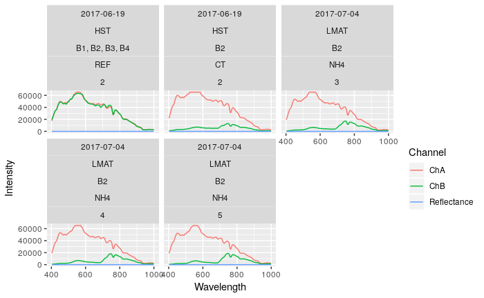

## 4.2 Check White References

White references correct for instrument & cable irregularities. Multiplying by the correction factor (ChA/ChB) smooths out the spectra. If multiple file numbers are listed (typically 5), the correction factors are averaged.

### 4.2.2 Plot Zoom Check References

Run the following code chunk interactively in RStudio to check references at specific sites/dates.

```r
# Useful Vectors for filtering
sites <- unlist(site_list)
dates <- df %>% select(Date) %>% unique() %>% slice(1:n()) %>% c() # list of dates present in data

## SPECIFY SITE/DATE/ETC to ZOOM IN ON
check_sites <- c("MNAT")
check_dates <- dates[[1]] # necessary to unlist dates vector

ref_check <- ref_data_all %>%
  filter(Date %in% check_dates) %>%
  filter(Site %in% check_sites)

## Plot Specified Correction Factors for quality check
cor_factor_plot_zoom <- ggplot(data = ref_check, mapping = aes(x = Wavelength, y = CorrectionFactor_REF)) +
  geom_line(aes(color=Treatment, linetype=Measurement, alpha=Block)) +
  facet_grid(Site ~ Date) +
  scale_alpha_discrete(range=c(1, 0.25))

cor_factor_plot_zoom
```

[output not shown]

Look at associated dataframe to check info, specifically: *Weather*, *Notes*, or *int* (Integration Time) columns.

## 4.3 Choose White References:

Based on the above quality check, choose reference files by entering the appropriate file numbers in **/home/ruby/UnispecR/UnispecData/2017/2017_unispec_key.csv** for the rows where the column *Treatment* = **REF**. There are typically 5 reference measurements per *Date* / *Site*.

## 4.4 Apply References by Key

Apply your chosen references to actual spectral data to create the tidy dataframe `df_tidy` containing corrected sepectral reflectance values.

# 5 Corrected Spectra

## 5.1 Save Spectral Data

```r
save <- F

if (save == T) {
  # SAVE CORRECTED SPECTRA if you want the dataframe or .csv for later
  unispec_data <- df_tidy %>%
    filter(Type=="correct") %>%
    select(-Type)
  write_rds(unispec_data, "unispec_data_correct.rds")
}
```

# 6 Investigate Spectral Data

## 6.2 Plot Spectra: Site vs. Date

# 7 Calculate Vegetation Indices

Currently, this only works for NDVI, EVI, and EVI2 as I haven’t worked out spectral interpolation yet and the other indices need reflectance at a specific value (not a range).

## 7.2 Save Vegetation Index Data

Append data to yearly r dataframe or .csv file. Write code to read in saved data and remove duplicate rows. >> ASK JIM: I’m not sure what the best data organization system is yet.